# TidyVersePart2Banu - Extend Forcats code by Salma

Banu Boopalan

12/7/2019

## Forcats package

forcats provides a suite of useful tools that solve common problems with factors. R uses factors to handle categorical variables, variables that have a fixed and known set of possible values.

In the following dataset, we have some categorical variables like **type_of_subject**, **subject_race**. R uses factors to handle those kinds of variables that have a fixed set of possible values. The forcats package goal is to provide a convenient tools that can solve some issues when dealing with factors, for example, changing the order of levels or the values. The following vignette will demonestrate more.

```r
if (!require('readr')) install.packages ('readr')
if (!require('forcats')) install.packages ('forcats')
if (!require('dplyr')) install.packages ('dplyr')
if (!require('kableExtra')) install.packages ('kableExtra')
if (!require('ggplot2')) install.packages ('ggplot2')
```

The following dataset is a collection of imdb movies including some data about release dat, country of origin,..etc. The dataset was imported from the fivethirtyeight github repo.

```r
url <- "https://raw.githubusercontent.com/fivethirtyeight/data/master/biopics/biopics.csv"
df <- read.csv(url, header = TRUE)
head(df)
```

```
##                 title                                 site country
## 1 10 Rillington Place http://www.imdb.com/title/tt0066730/      UK
## 2    12 Years a Slave http://www.imdb.com/title/tt2024544/   US/UK
## 3           127 Hours http://www.imdb.com/title/tt1542344/   US/UK
## 4                1987 http://www.imdb.com/title/tt2833074/  Canada
## 5            20 Dates http://www.imdb.com/title/tt0138987/      US
## 6                  21 http://www.imdb.com/title/tt0478087/      US
##   year_release box_office          director number_of_subjects
## 1         1971          - Richard Fleischer                  1
## 2         2013     $56.7M     Steve McQueen                  1
## 3         2010     $18.3M       Danny Boyle                  1
## 4         2014          -     Ricardo Trogi                  1
## 5         1998      $537K   Myles Berkowitz                  1
## 6         2008     $81.2M    Robert Luketic                  1
##            subject type_of_subject race_known     subject_race
## 1    John Christie        Criminal    Unknown
## 2  Solomon Northup           Other      Known African American
## 3     Aron Ralston         Athlete    Unknown
## 4    Ricardo Trogi           Other      Known            White
## 5  Myles Berkowitz           Other    Unknown
## 6          Jeff Ma           Other      Known   Asian American
##   person_of_color subject_sex   lead_actor_actress
## 1               0        Male Richard Attenborough
## 2               1        Male     Chiwetel Ejiofor
## 3               0        Male         James Franco
## 4               0        Male    Jean-Carl Boucher
## 5               0        Male      Myles Berkowitz
## 6               1        Male         Jim Sturgess
```

If I tried to plot the **type_of_subject** variable as the illustrated below, you will find that the bars haven’t distributed uniformly even if you forced them to reorder.

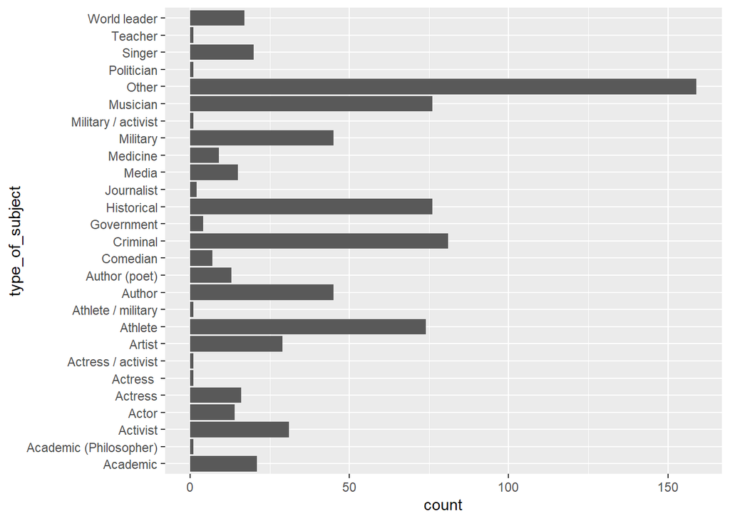

```r
df_2 <- df %>%
  arrange(type_of_subject)

ggplot(df_2, aes(x = type_of_subject)) +
  geom_bar() +
  coord_flip()
```

To solve this problem, you can use the **fct_infreq()** wich is ships within the **forcats** package. This function is responsible for reordering a factor variable by the frequency of value - notice the change below:

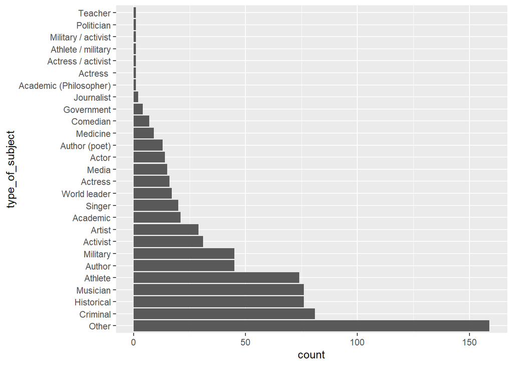

```r
df %>%
  mutate(type_of_subject = fct_infreq(type_of_subject)) %>%
  ggplot(aes(x = type_of_subject)) +
  geom_bar() +
  coord_flip()
```

Pretty neat! you can easily identify the trends from graphs without any extra processing.

Extention by Banu : Here, I am reordering the least common levels into Other value so all females are mapped to other

```r
str(df)
```

```
## 'data.frame':    761 obs. of  14 variables:
##  $ title             : Factor w/ 668 levels "10 Rillington Place",..: 1 2 3 4 5 6 7 8 9 10 ...
##  $ site              : Factor w/ 672 levels "http://www.imdb.com/title/tt0005960/",..: 178 645 614 668 380 524 418 508 317 249 ...
##  $ country           : Factor w/ 7 levels "Canada","Canada/UK",..: 3 6 6 1 4 4 3 4 4 6 ...
##  $ year_release      : int  1971 2013 2010 2014 1998 2008 2002 2013 1994 1987 ...
##  $ box_office        : Factor w/ 338 levels "-","$1.01M","$1.03M",..: 1 275 94 1 268 316 10 334 102 6 ...
##  $ director          : Factor w/ 488 levels " Brian Helgeland",..: 369 444 89 366 319 389 305 1 213 98 ...
##  $ number_of_subjects: int  1 1 1 1 1 1 1 1 1 2 ...
##  $ subject           : Factor w/ 699 levels " Pierre Durand, Jr.",..: 388 2 48 558 501 353 653 323 424 215 ...
##  $ type_of_subject   : Factor w/ 27 levels "Academic","Academic (Philosopher)",..: 14 23 9 23 23 23 22 9 9 11 ...
##  $ race_known        : Factor w/ 2 levels "Known","Unknown": 2 1 2 1 2 1 1 1 2 2 ...
##  $ subject_race      : Factor w/ 18 levels "","African","African American",..: 1 3 1 18 1 5 18 3 1 1 ...
##  $ person_of_color   : int  0 1 0 0 0 1 0 1 0 0 ...
##  $ subject_sex       : Factor w/ 2 levels "Female","Male": 2 2 2 2 2 2 2 2 2 2 ...
##  $ lead_actor_actress: Factor w/ 575 levels "","-"," Caveh Zahedi",..: 446 84 243 257 395 276 513 76 344 32 ...
```

```r
 df1 <- df
 df1 %>%
  mutate(subject_sex = fct_lump(subject_sex)) %>%
  count(subject_sex)
```

```
## # A tibble: 2 x 2
##   subject_sex     n
##   <fct>       <int>
## 1 Male          584
## 2 Other         177
```

```r
df1[1:500,] %>%
  mutate(lead_actor_actress = fct_lump(lead_actor_actress)) %>%
   count(lead_actor_actress) %>% arrange(desc(n)) %>% top_n(10)
```

```
## # A tibble: 15 x 2
##    lead_actor_actress     n
##    <fct>              <int>
##  1 Johnny Depp            5
##  2 Anthony Hopkins        4
##  3 Denzel Washington      4
##  4 Gary Oldman            4
##  5 Hilary Swank           4
##  6 Liam Neeson            4
##  7 Paul Newman            4
##  8 Burt Lancaster         3
##  9 Daniel Day-Lewis       3
## 10 Ed Harris              3
## 11 Emile Hirsch           3
## 12 Meryl Streep           3
## 13 Robert Taylor          3
## 14 Robin Williams         3
## 15 Tom Hanks              3
```